# MovieLens Project Questions

### 8. Visualize how popularity of genres has changed over the years - 10 marks

Note that you need to use the number of releases in a year as a parameter of popularity of a genre

Hint

1: you need to reach to a data frame where the release year is the index and the genre is the column names (one cell shows the number of release in a year in one genre) or vice versa. Once that is achieved, you can either use multiple bivariate plots or can use the heatmap to visualise all the changes over the years in one go.

Hint 2: Use groupby on the relevant column and use sum() on the same to find out the nuumber of releases in a year/genre.

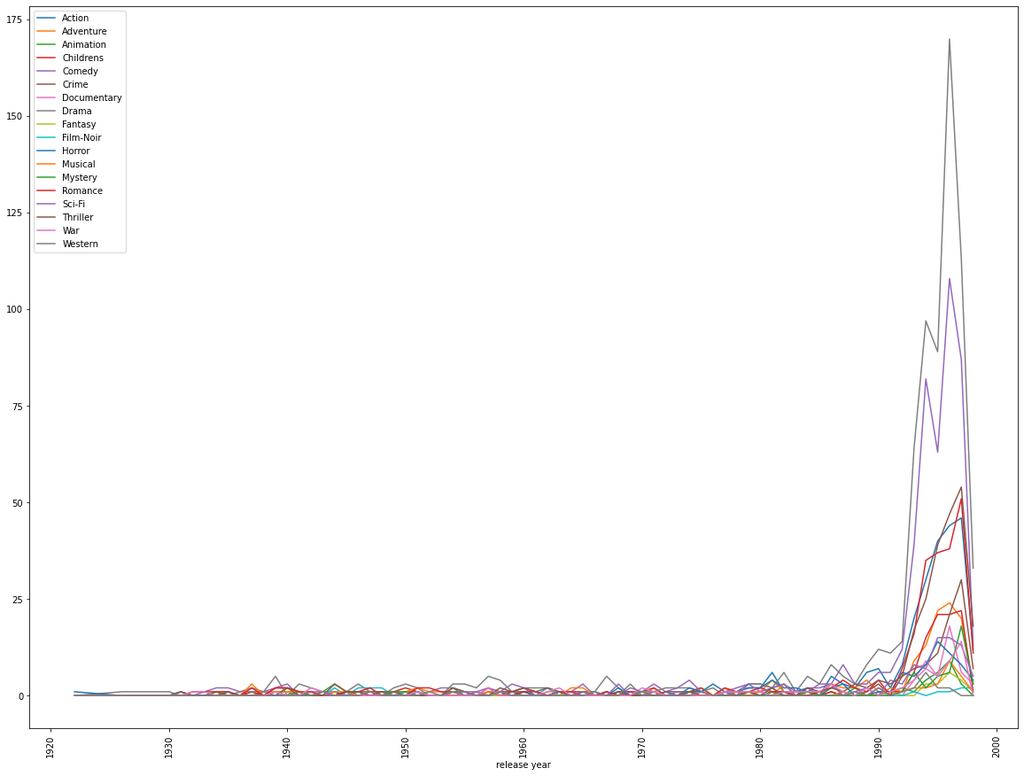

```python
dfItem[['release year','Action', 'Adventure', 'Animation', 'Childrens', 'Comedy', 'Crime', 'Documentary','Drama', 'Fantasy',
       'Film-Noir', 'Horror', 'Musical', 'Mystery', 'Romance', 'Sci-Fi', 'Thriller', 'War', 'Western']].groupby(['release year']).sum().plot(figsize=(20,15))
plt.xticks(rotation=90)
plt.show()
```

### 9. Find the top 25 movies according to average ratings such that each movie has number of ratings more than 100 - 10 marks

Hint :

1. First find the movies that have more than 100 ratings(use groupby and count). Extract the movie id in a list.
2. Find the average rating of all the movies and sort them in the descending order.
3. Use isin(list obtained from 1) to filter out the movies which have more than 100 ratings.
4. You will have to use the .merge() function to get the movie titles.

Note: This question will need you to research about groupby and apply your findings. You can find more on groupby on https://realpython.com/pandas-groupby/.

```python
dfData.drop(['timestamp'], axis=1, inplace=True)
dfData.head()
```

|  | user id | movie id | rating |
| --- | --- | --- | --- |
| 0 | 196 | 242 | 3 |
| 1 | 186 | 302 | 3 |
| 2 | 22 | 377 | 1 |
| 3 | 244 | 51 | 2 |
| 4 | 166 | 346 | 1 |

```python
dfData=dfData.merge(dfItem,on='movie id', how='left')
dfData.head()
```

|  | user id | movie id | rating | movie title | release date | unknown | Action | Adventure | Animation | Childrens | ... | Horror | Musical | Mystery | Romance | Sci-Fi | Thriller | War | Western | NumGenres | release year |
| --- | --- | --- | --- | --- | --- | --- | --- | --- | --- | --- | --- | --- | --- | --- | --- | --- | --- | --- | --- | --- | --- |
| 0 | 196 | 242 | 3 | Kolya | 24-Jan-1997 | 0.0 | 0.0 | 0.0 | 0.0 | 0.0 | ... | 0.0 | 0.0 | 0.0 | 0.0 | 0.0 | 0.0 | 0.0 | 0.0 | 1.0 | 1997.0 |
| 1 | 186 | 302 | 3 | L.A. Confidential | 01-Jan-1997 | 0.0 | 0.0 | 0.0 | 0.0 | 0.0 | ... | 0.0 | 0.0 | 1.0 | 0.0 | 0.0 | 1.0 | 0.0 | 0.0 | 4.0 | 1997.0 |
| 2 | 22 | 377 | 1 | Heavyweights | 01-Jan-1994 | 0.0 | 0.0 | 0.0 | 0.0 | 1.0 | ... | 0.0 | 0.0 | 0.0 | 0.0 | 0.0 | 0.0 | 0.0 | 0.0 | 2.0 | 1994.0 |
| 3 | 244 | 51 | 2 | Legends of the Fall | 01-Jan-1994 | 0.0 | 0.0 | 0.0 | 0.0 | 0.0 | ... | 0.0 | 0.0 | 0.0 | 1.0 | 0.0 | 0.0 | 1.0 | 1.0 | 4.0 | 1994.0 |
| 4 | 166 | 346 | 1 | Jackie Brown | 01-Jan-1997 | 0.0 | 0.0 | 0.0 | 0.0 | 0.0 | ... | 0.0 | 0.0 | 0.0 | 0.0 | 0.0 | 0.0 | 0.0 | 0.0 | 2.0 | 1997.0 |

5 rows × 26 columns

```python
movie_stats = dfData.groupby('movie title').agg({'rating': [np.size, np.mean]})
movie_stats.head()
```

| movie title | rating size | rating mean |
| --- | --- | --- |
| 'Til There Was You | 9 | 2.333333 |
| 1-900 | 5 | 2.600000 |
| 101 Dalmatians | 109 | 2.908257 |
| 12 Angry Men | 125 | 4.344000 |
| 187 | 41 | 3.024390 |

```python
WidelyReviewed = movie_stats['rating']['size'] >= 100
movie_stats[WidelyReviewed].sort_values([('rating', 'mean')], ascending=False)[:25]
```

| movie title | rating size | rating mean |
| --- | --- | --- |
| Close Shave, A | 112 | 4.491071 |
| Schindler's List | 298 | 4.466443 |
| Wrong Trousers, The | 118 | 4.466102 |
| Casablanca | 243 | 4.456790 |
| Shawshank Redemption, The | 283 | 4.445230 |
| Rear Window | 209 | 4.387560 |
| Usual Suspects, The | 267 | 4.385768 |
| Star Wars | 583 | 4.358491 |
| 12 Angry Men | 125 | 4.344000 |
| Citizen Kane | 198 | 4.292929 |
| To Kill a Mockingbird | 219 | 4.292237 |
| One Flew Over the Cuckoo's Nest | 264 | 4.291667 |
| Silence of the Lambs, The | 390 | 4.289744 |
| North by Northwest | 179 | 4.284916 |
| Godfather, The | 413 | 4.283293 |
| Secrets & Lies | 162 | 4.265432 |
| Good Will Hunting | 198 | 4.262626 |
| Manchurian Candidate, The | 131 | 4.259542 |
| Dr. Strangelove or: How I Learned to Stop Worrying and Love the Bomb | 194 | 4.252577 |
| Raiders of the Lost Ark | 420 | 4.252381 |
| Vertigo | 179 | 4.251397 |
| Titanic | 350 | 4.245714 |
| Lawrence of Arabia | 173 | 4.231214 |
| Maltese Falcon, The | 138 | 4.210145 |
| Empire Strikes Back, The | 367 | 4.204360 |

### 10. See gender distribution across different genres check for the validity of the below statements - 10 marks

- Men watch more drama than women
- Women watch more Sci-Fi than men
- Men watch more Romance than women

**compare the percentages**

1. There is no need to conduct statistical tests around this. Just **compare the percentages** and comment on the validity of the above statements.
2. you might want ot use the .sum(), .div() function here.
3. Use number of ratings to validate the numbers. For example, if out of 4000 ratings received by women, 3000 are for drama, we will assume that 75% of the women watch drama.

#### Conclusion:

```python
dfData.head()
```

|  | user id | movie id | rating | movie title | release date | unknown | Action | Adventure | Animation | Childrens | ... | Horror | Musical | Mystery | Romance | Sci-Fi | Thriller | War | Western | NumGenres | release year |
| --- | --- | --- | --- | --- | --- | --- | --- | --- | --- | --- | --- | --- | --- | --- | --- | --- | --- | --- | --- | --- | --- |
| 0 | 196 | 242 | 3 | Kolya | 24-Jan-1997 | 0.0 | 0.0 | 0.0 | 0.0 | 0.0 | ... | 0.0 | 0.0 | 0.0 | 0.0 | 0.0 | 0.0 | 0.0 | 0.0 | 1.0 | 1997.0 |
| 1 | 186 | 302 | 3 | L.A. Confidential | 01-Jan-1997 | 0.0 | 0.0 | 0.0 | 0.0 | 0.0 | ... | 0.0 | 0.0 | 1.0 | 0.0 | 0.0 | 1.0 | 0.0 | 0.0 | 4.0 | 1997.0 |
| 2 | 22 | 377 | 1 | Heavyweights | 01-Jan-1994 | 0.0 | 0.0 | 0.0 | 0.0 | 1.0 | ... | 0.0 | 0.0 | 0.0 | 0.0 | 0.0 | 0.0 | 0.0 | 0.0 | 2.0 | 1994.0 |
| 3 | 244 | 51 | 2 | Legends of the Fall | 01-Jan-1994 | 0.0 | 0.0 | 0.0 | 0.0 | 0.0 | ... | 0.0 | 0.0 | 0.0 | 1.0 | 0.0 | 0.0 | 1.0 | 1.0 | 4.0 | 1994.0 |
| 4 | 166 | 346 | 1 | Jackie Brown | 01-Jan-1997 | 0.0 | 0.0 | 0.0 | 0.0 | 0.0 | ... | 0.0 | 0.0 | 0.0 | 0.0 | 0.0 | 0.0 | 0.0 | 0.0 | 2.0 | 1997.0 |

5 rows × 26 columns

```python
#Merge user data into dfData
DF = pd.merge(dfData, dfUser)
DF.head()
```

|  | user id | movie id | rating | movie title | release date | unknown | Action | Adventure | Animation | Childrens | ... | Sci-Fi | Thriller | War | Western | NumGenres | release year | age | gender | occupation | zip code |
| --- | --- | --- | --- | --- | --- | --- | --- | --- | --- | --- | --- | --- | --- | --- | --- | --- | --- | --- | --- | --- | --- |
| 0 | 196 | 242 | 3 | Kolya | 24-Jan-1997 | 0.0 | 0.0 | 0.0 | 0.0 | 0.0 | ... | 0.0 | 0.0 | 0.0 | 0.0 | 1.0 | 1997.0 | 49 | M | writer | 55105 |
| 1 | 196 | 393 | 4 | Mrs. Doubtfire | 01-Jan-1993 | 0.0 | 0.0 | 0.0 | 0.0 | 0.0 | ... | 0.0 | 0.0 | 0.0 | 0.0 | 1.0 | 1993.0 | 49 | M | writer | 55105 |
| 2 | 196 | 381 | 4 | Muriel's Wedding | 01-Jan-1994 | 0.0 | 0.0 | 0.0 | 0.0 | 0.0 | ... | 0.0 | 0.0 | 0.0 | 0.0 | 2.0 | 1994.0 | 49 | M | writer | 55105 |
| 3 | 196 | 251 | 3 | Shall We Dance? | 11-Jul-1997 | 0.0 | 0.0 | 0.0 | 0.0 | 0.0 | ... | 0.0 | 0.0 | 0.0 | 0.0 | 1.0 | 1997.0 | 49 | M | writer | 55105 |
| 4 | 196 | 655 | 5 | Stand by Me | 01-Jan-1986 | 0.0 | 0.0 | 1.0 | 0.0 | 0.0 | ... | 0.0 | 0.0 | 0.0 | 0.0 | 3.0 | 1986.0 | 49 | M | writer | 55105 |

5 rows × 30 columns

```python
#Check the number of Drama movies watched.
RatedDrama = DF.groupby(['Drama']).agg({'rating': 'count'})
print(RatedDrama)
print()
DramabyGender = DF.groupby(['gender']).agg({'Drama': 'sum'})
print(DramabyGender)
print()
DramabyGender['Percentages']=(DramabyGender['Drama'] /
                  DramabyGender['Drama'].sum()) * 100
print(DramabyGender)
print()
print("Men watch more drama movies than women.")
```

```
       rating
Drama
0.0     60096
1.0     39895

          Drama
gender
F       11008.0
M       28887.0

          Drama  Percentages
gender
F       11008.0     27.59243
M       28887.0     72.40757

Men watch more drama movies than women.
```

```python
#Check the number of Sci-Fi movies watched.
RatedSciFi = DF.groupby(['Sci-Fi']).agg({'rating': 'count'})
print(RatedSciFi)
print()
SciFibyGender = DF.groupby(['gender']).agg({'Sci-Fi': 'sum'})
print(SciFibyGender)
print()
SciFibyGender['Percentages']=(SciFibyGender['Sci-Fi'] /
                  SciFibyGender['Sci-Fi'].sum()) * 100
print(SciFibyGender)
print()
print("Women do not watch more sci-fi movies than men.")
```

```
        rating
Sci-Fi
0.0      87261
1.0      12730

         Sci-Fi
gender
F        2629.0
M       10101.0

         Sci-Fi  Percentages
gender
F        2629.0    20.652003
M       10101.0    79.347997

Women do not watch more sci-fi movies than men.
```

```python
#Check the number of Drama movies watched.
RatedRomance = DF.groupby(['Romance']).agg({'rating': 'count'})
print(RatedRomance)
print()
RomancebyGender = DF.groupby(['gender']).agg({'Romance': 'sum'})
print(RomancebyGender)
print()
RomancebyGender['Percentages']=(RomancebyGender['Romance'] /
                  RomancebyGender['Romance'].sum()) * 100
print(RomancebyGender)
print()
print("Men do actually watch more romance movies than women.")
```

```
         rating
Romance
0.0       80530
1.0       19461

        Romance
gender
F        5858.0
M       13603.0

        Romance  Percentages
gender
F        5858.0    30.101228
M       13603.0    69.898772

Men do actually watch more romance movies than women.
```